# Machine Learning II (Master en Data Science, UIMP-UC)

# Tarea: Redes Bayesianas

### Fecha de entrega: 7 Abril 2019

Responde a las preguntas planteadas y aporta el código en R utilizado para responderlas. Se debe enviar un único documento con texto y código entrelazado, bien sea en formato pdf o html.

## Introducción a la práctica

Utilizaremos un conjunto de datos diarios de ocurrencia de meteoros en el aeropuerto de Parayas (Santander), considerando una serie de variables meteorológicas registradas diariamente durante un periodo aproximado de 10 años (3286 registros), en concreto: precipitación, nieve, granizo, tormenta, niebla, rocío, escarcha, nieve en el suelo, neblina y racha máxima de viento superior a 50 km/h. Los datos se encuentran guardados en el fichero de texto `meteoro.txt`. Las variables se encuentran discretizadas de forma binaria (ocurrencia/ausencia).

## Ejercicio 1 (2.5 Puntos)

- A partir del grafo dado por el experto, determina la expresión que refleja la factorización de la distribución global, y escríbela como una secuencia de caracteres del tipo generado por la función `modelstring` del paquete de R `bnlearn`.

```r
library(bnlearn)
library(gRain)
library(Rgraphviz)
```

```r
model.string <- "[viento][lluvia|viento][rocio|viento][niebla|viento:rocio][escarcha|rocio][neblina|niebla][tormenta|lluvia][granizo|tormenta][nieve|tormenta][nieveSuelo|nieve]"
```

NOTA: Como ya se comentado anteriormente, es importante evitar tildes a la hora de nombrar los nodos. Tampoco son recomendables espacios en blanco ni ningún tipo de carácter especial.

- A continuación, introduce el DAG en R utilizando la definicíon del modelo que acabas de crear

```r
dag <- model2network(model.string)
graphviz.plot(dag)
```

[output not shown]

- Realiza una lista de los padres e hijos de cada uno de los nodos

```r
# Padres de un determinado nodo
nodes = bnlearn::nodes(dag)

#Creo dos listas para guardar los padres e hijos

parents = list()
children = list()
for (node in nodes) {
    parents[[node]] <- bnlearn::parents(dag, node)
    children[[node]] <- bnlearn::children(dag, node)
}
print('Padres')
print(parents)
print('Hijos')
print(children)

#Caracther(0) significa que el nodo no tiene padre o hijo respectivamente
```

```
[1] "Padres"
$escarcha
[1] "rocio"

$granizo
[1] "tormenta"

$lluvia
[1] "viento"

$neblina
[1] "niebla"

$niebla
[1] "rocio"  "viento"

$nieve
[1] "tormenta"

$nieveSuelo
[1] "nieve"

$rocio
[1] "viento"

$tormenta
[1] "lluvia"

$viento
character(0)

[1] "Hijos"
$escarcha
character(0)

$granizo
character(0)

$lluvia
[1] "tormenta"

$neblina
character(0)

$niebla
[1] "neblina"

$nieve
[1] "nieveSuelo"

$nieveSuelo
character(0)

$rocio
[1] "escarcha" "niebla"

$tormenta
[1] "granizo" "nieve"

$viento
[1] "lluvia" "niebla" "rocio"
```

- Realiza una lista de todas las conexiones fundamentales presentes en el grafo, y realiza una clasificación de cada una de ellas determinando si es una estructura en serie, divergente o convergente.
- ¿Se observa alguna *v-estructura* en el grafo?

```r
v_estructura <- bnlearn::vstructs(dag)
v_estructura
```

| X | Z | Y |
| --- | --- | --- |

- Intenta introducir un arco que parta del nodo neblina y se dirija hacia escarcha, y otro que vaya de granizo a lluvia. Comenta qué sucede en cada caso, y si el resultado daría lugar a una red bayesiana válida.

```r
caso1 <- set.arc(dag, from = "neblina", to = "escarcha")
```

```r
tryCatch(set.arc(dag, from = "granizo", to = "lluvia"),
    error = function(e)
    print("No se puede añadir el arco"))
```

```
[1] "No se puede añadir el arco"
```

**Caso 1**

Al introducir el arco from Neblina to Escarcha se dibuja el arco y se forma una V-estructura tal que Neblina -> Escarcha <- Rocio.

**Caso 2**

Al introducir el arco from granizo to lluvia no es posible dibujar el arco. Esto es debido a que se produciria un ciclo en el grafo, no siendo el grafo una red bayesiana valida.

- Determina la manta de Markov del nodo `rocio`

```r
mb(dag, "rocio")
```

1. 'escarcha'

2. 'niebla'

3. 'viento'

- Introduce un arco que parta del nodo Lluvia y se dirija al nodo Niebla, ¿cambia la manta de Markov del nodo `rocio`? En caso afirmativo, ¿cómo lo hace?

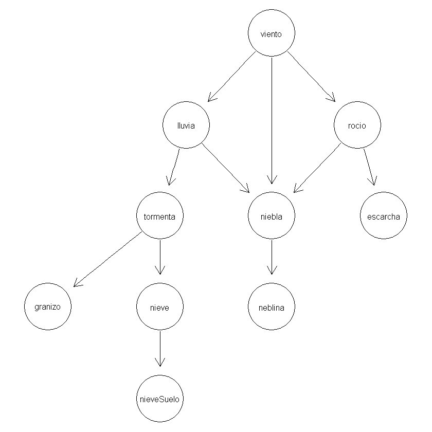

```r
caso3 <- set.arc(dag, from = "lluvia", to = "niebla")
graphviz.plot(caso3)
```

```r
mb(caso3, "rocio")

#Lo que ocurre es que al añadir el arco, niebla pasa a ser hijo de lluvia y rocio y por tanto lluvia entra en la
#market de markov de rocio
```

1. 'escarcha'

2. 'lluvia'

3. 'niebla'

4. 'viento'

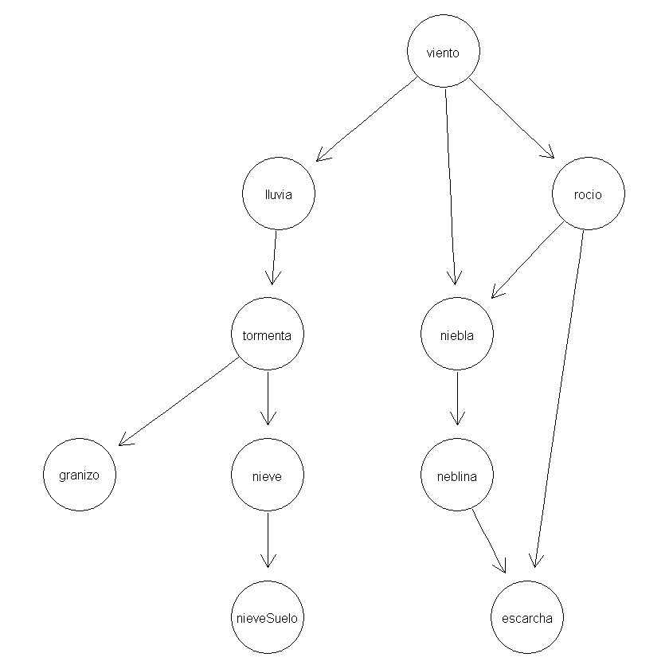

```r
#NOTA
#Grafo original
graphviz.plot(dag)
#Grafo eliminando el arco entre lluvia y niebla
graphviz.plot(caso1)
```

NOTA: Para continuar, elimina el arco definido anteriormente entre los nodos Lluvia y Niebla, recuperando el DAG original.

## Ejercicio 2 (2.5 Puntos)

- Considerando la información proporcionada por el conjunto de datos `meteor`, construye la red bayesiana utilizando el método bayesiano de estimación paramétrica.

```r
meteor <- read.table("meteoro.txt", header = TRUE)
```

```r
head(meteor,2)
tail(meteor,2)
```

| lluvia | nieve | granizo | tormenta | niebla | rocio | escarcha | nieveSuelo | neblina | viento |
| --- | --- | --- | --- | --- | --- | --- | --- | --- | --- |
| s | n | n | n | n | n | n | n | n | s |
| s | n | n | n | n | n | n | n | n | s |

|  | lluvia | nieve | granizo | tormenta | niebla | rocio | escarcha | nieveSuelo | neblina | viento |
| --- | --- | --- | --- | --- | --- | --- | --- | --- | --- | --- |
| 3285 | s | n | n | n | n | s | n | n | s | n |
| 3286 | s | n | n | n | n | n | n | n | s | n |

- ¿Cuál sería el número potencial de parámetros (sin usar la red bayesiana) del modelo para calcular la probabilidad global si no utilizasemos el DAG?

```r
parameters=2**10

cat("Al tener 10 nodos y cada uno de ellos tomar valores binarios tenemos que el número potencial
de parametros es:",
parameters)
```

```
Al tener 10 nodos y cada uno de ellos tomar valores binarios tenemos que el número potencial
de parametros es: 1024
```

- ¿Cuántos parámetros tiene la distribución global dada por la red bayesiana?

```r
bn.bayes <- bn.fit(dag, meteor, method = "bayes")
```

```r
nparams(bn.bayes)
```

21

- Determina el número de parámetros asociado a cada una de las distribuciones locales

```r
lista <- list()
suma <- 0
for (node in nodes(dag)) {
    lista[[node]] <- ifelse(node=='viento',1, 2*length(bnlearn::parents(dag, node)))
    suma = suma + lista[[node]]
}
lista
suma
```

**$escarcha**

2

**$granizo**

2

**$lluvia**

2

**$neblina**

2

**$niebla**

4

**$nieve**

2

**$nieveSuelo**

2

**$rocio**

2

**$tormenta**

2

**$viento**

1

21

- Obtén las tablas de probabilidad condicional asociadas los nodos `granizo` y `niebla`. Ahora representa la información de cada tabla en sendos gráficos.

```r
bn.granizo <- bn.bayes$granizo
bn.granizo
```

```
  Parameters of node granizo (multinomial distribution)

Conditional probability table:

       tormenta
granizo           n           s
      n 0.990183352 0.745742092
      s 0.009816648 0.254257908
```

```r
bn.niebla <- bn.bayes$niebla
bn.niebla
```

```
  Parameters of node niebla (multinomial distribution)

Conditional probability table:

, , viento = n

      rocio
niebla           n           s
     n 0.946399802 0.855234203
     s 0.053600198 0.144765797

, , viento = s

      rocio
niebla           n           s
     n 0.995195025 0.934108527
     s 0.004804975 0.065891473
```

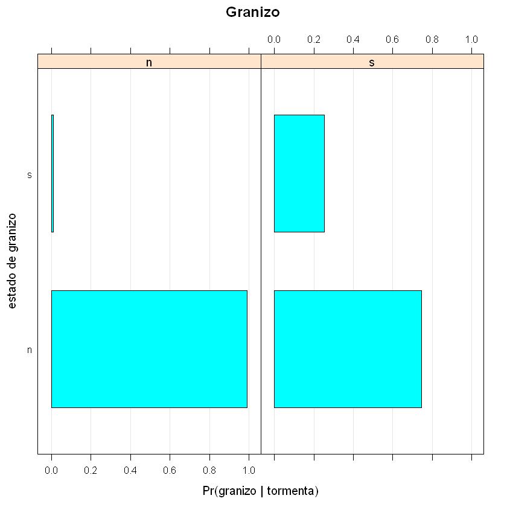

```r
# Barras Granizo
bn.fit.barchart(bn.granizo, main = "Granizo", xlab = "Pr(granizo | tormenta)", ylab = "estado de granizo")
```

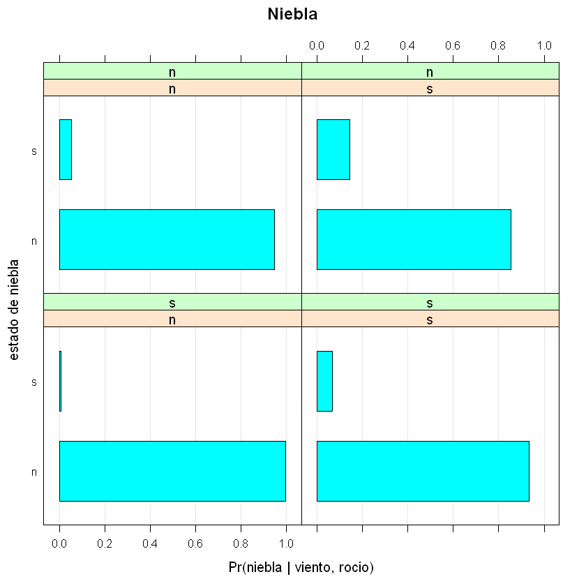

```r
# Barras Niebla
bn.fit.barchart(bn.niebla, main = "Niebla", xlab = "Pr(niebla | viento, rocio)", ylab = "estado de niebla")
```

## Ejercicio 3 (2.5 Puntos)

Una vez construída la red hemos establecido la base de conocimiento del sistema inteligente. A continuación se puede calcular la probabilidad de cualquier variable o conjunto de variables condicionadas a cualquier evidencia que se tenga disponible para un problema dado, es decir, realizar la inferencia.

- Observa la estructura del DAG y repasa la teoría y el concepto de *d-separación*. Responde razonadamente si las siguientes afirmaciones son verdaderas o falsas, utilizando únicamente la estructura del DAG y el concepto de d-separación:
  - La nieve y el granizo son fenómenos independientes a priori
  - La nieve y el granizo son fenómenos independientes dado que haya habido tormenta
  - La nieve en el suelo y la neblina son fenómenos independientes
  - La nieve en el suelo y la neblina son fenómenos independientes dado que haya habido tormenta

```r
graphviz.plot(dag)
```

[output not shown]

- La nieve y el granizo son fenómenos independientes a priori

```r
dsep(dag, "nieve", "granizo")
```

FALSE

- La nieve y el granizo son fenómenos independientes dado que haya habido tormenta

```r
dsep(dag, "nieve", "granizo", "tormenta")
```

TRUE

- La nieve en el suelo y la neblina son fenómenos independientes

```r
dsep(dag, "nieveSuelo", "neblina")
```

FALSE

- La nieve en el suelo y la neblina son fenómenos independientes dado que haya habido tormenta

```r
dsep(dag, "nieveSuelo", "neblina", "tormenta")
```

TRUE

- NOTA: En este apartado se deberá aplicar la inferencia exacta. Conocido que en un día dado se han producido tormentas, calcula cómo afecta este hecho a la probabilidad de que se produzcan los siguientes fenómenos meteorológicos:
  - Que llueva, $P(lluvia = s | tormenta = s)$

```r
estudio_probabilidades <- compile(as.grain(bn.bayes))
```

```r
jtorm <- setEvidence(object = estudio_probabilidades, nodes = "tormenta", states = "s")
querygrain(jtorm, nodes = "lluvia")$lluvia
```

**n**

0.0401459854014599

**s**

0.95985401459854

```r
#Esto significa que hay un 95.9% de probabilidades de que llueva cuando hay tormenta
```

```
* Que haya rachas de viento superiores a 50 Km/h, $P(viento = s | tormenta = s)$
```

```r
querygrain(jtorm, nodes = "viento")$viento
```

**n**

0.78313921062555

**s**

0.216860789374449

```r
#Esto significa que hay un 21.6% de probabilidades de que haga viento cuando hay tormenta
```

```
* Que llueva y que además las rachas de viento superen los 50 Km/h, $P(lluvia = s, viento = n | tormenta = s)$
```

```r
querygrain(jtorm, nodes = c("lluvia", "viento"), type = "joint")
```

|  | n | s |
| --- | --- | --- |
| n | 0.038352404 | 0.7447868 |
| s | 0.001793581 | 0.2150672 |

```r
#Viendo la tabla tenemos que hay un 21.5% de probabilidades de que habiendo tormenta, haya lluvia y viento.

#Se cumple que:
#              $P(lluvia = s, viento = s | tormenta = s) < $P( viento = s | tormenta = s)
#                                               0.215    <    0.216
#              $P(lluvia = s, viento = s | tormenta = s) < $P( lluvia = s | tormenta = s)
#                                               0.215    <    0.959
```

```
* A partir de la información revelada por la red bayesiana, sabiendo que un día se producen tormentas:
    * ¿Hay mayor probabilidad de que llueva cuando se producen tormentas que cualquier otro día?
```

```r
querygrain(estudio_probabilidades, nodes = "lluvia")$lluvia
```

**n**

0.444326133252206

**s**

0.555673866747794

```r
#la probabildiad de lluvia un dia cualquiera es de 55.5%

#Como hemos visto antes la probabildiad de lluvia cuando hay tormenta es de un 95.9%

#Por tanto, aumento la probabilidad de lluvia cuando hay tormenta respecto a un dia cualquiera
```

```
    * ¿Aumenta o disminuye la probabilidad de tener rachas de viento mayores de 50 Km/h cuando se produce tormenta? ¿Cuánto?
```

```r
querygrain(estudio_probabilidades, nodes = "viento")$viento
```

**n**

0.85564344386979

**s**

0.14435655613021

```r
#la probabildiad de viento un dia cualquiera es de 14.4%

#Como hemos visto antes la probabildiad de viento cuando hay tormenta es de un 21.6%

#Por tanto, aumenta la probabilidad de viento cuando hay tormenta respecto a un dia cualquiera
```

- Dado el ejercicio anterior, repetir ahora el ejercicio mediante inferencia aproximada, calculando para cada una de las estimaciones 100 realizaciones. Para cada una de las respuestas anteriores, representa un diagrama de cajas que represente la dispersión en la estimación de la probabilidad, marcando además el valor obtenido de manera exacta en el apartado anterior.

```
* Que llueva, $P(lluvia = s | tormenta = s)$
```

```r
prob_100_r <- as.numeric(seq(1:100))
for (i in 1:length(prob_100_r)) {
    prob_100_r[i] <- cpquery(fitted=bn.bayes, event = lluvia == "s", evidence = tormenta == "s")
}
```

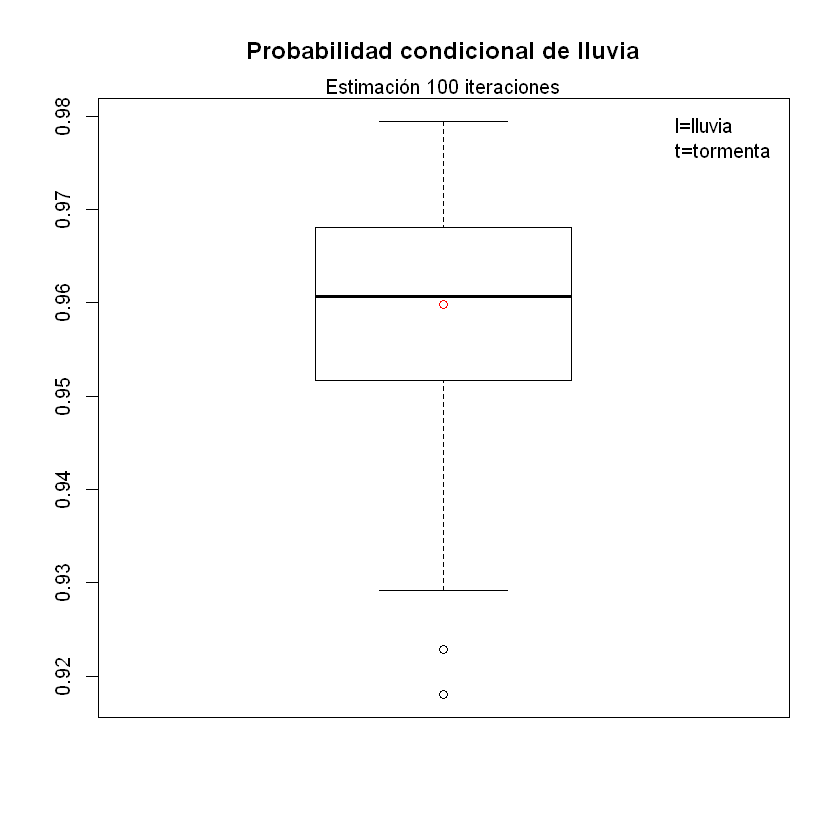

```r
boxplot(prob_100_r, main = "Probabilidad condicional de lluvia")
mtext("Estimación 100 iteraciones")
legend("topright", c("l=lluvia","t=tormenta"), bty = "n")
points(querygrain(jtorm, nodes = "lluvia")$lluvia[2], col = "red")
```

```
* Que haya rachas de viento superiores a 50 Km/h, $P(viento = s | tormenta = s)$
```

```r
prob_100_v <- as.numeric(1:100)
for (i in 1:length(prob_100_v)) {
    prob_100_v[i] <- cpquery(fitted=bn.bayes, event = viento == "s", evidence = (tormenta == "s"))
}
```

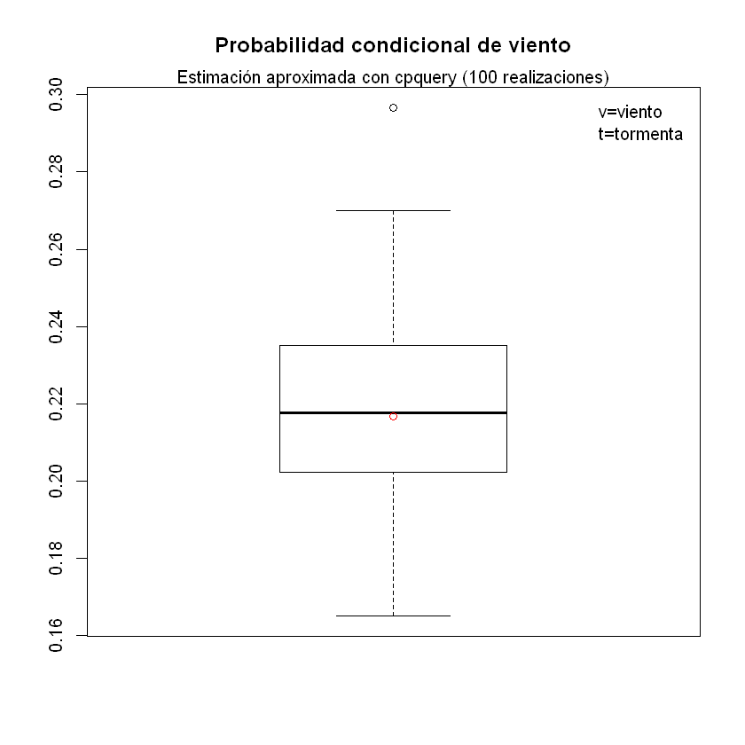

```r
boxplot(prob_100_v, main = "Probabilidad condicional de viento")
mtext("Estimación aproximada con cpquery (100 realizaciones)")
legend("topright", c("v=viento","t=tormenta"), bty = "n")

points(querygrain(jtorm, nodes = "viento")$viento[2], col = "red")
```

```r
prob_100_v_r <- as.numeric(1:100)
for (i in 1:length(prob_100_v_r)) {
    prob_100_v_r[i] <- cpquery(fitted=bn.bayes,
                               event = (viento == "s" & lluvia=="s"), evidence = (tormenta == "s"))
}
```

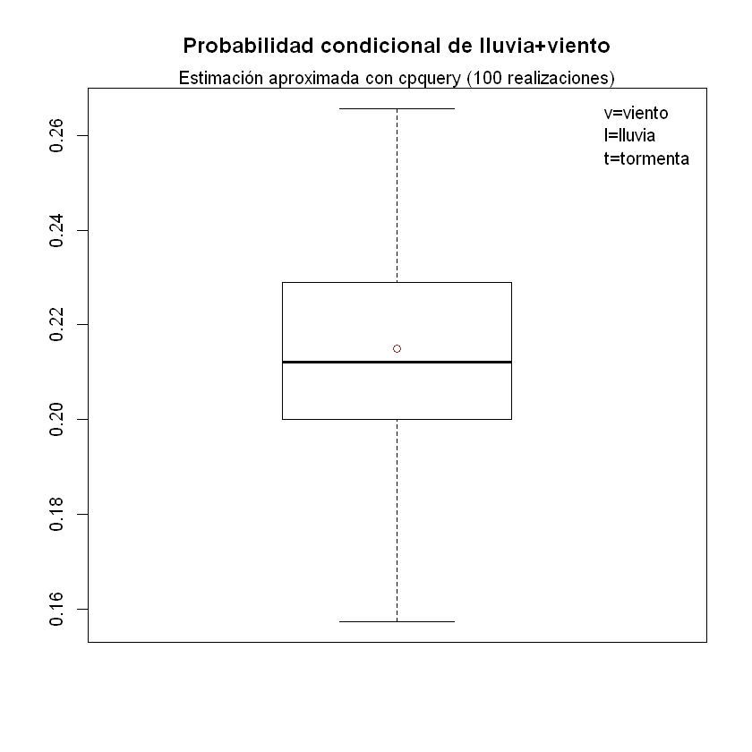

```r
boxplot(prob_100_v_r, main = "Probabilidad condicional de lluvia+viento")
mtext("Estimación aproximada con cpquery (100 realizaciones)")
legend("topright", c("v=viento","l=lluvia", "t=tormenta"), bty = "n")

points(querygrain(jtorm, nodes = c("lluvia", "viento"), type="joint")[2,2], col = "brown")
```

## Ejercicio 4 (2.5 Puntos)

Como hemos visto, es posible realizar un aprendizaje automático de la estructura del DAG a partir de los datos, usando algoritmos específicos para ello. Durante las clases hemos visto el ejemplo del algoritmo *hill-climbing*, aunque como vimos, hay otras posibilidades. Tambien hemos visto que podemos combinar nuestra experiencia y el aprendizaje automático definiendo previamente relaciones entre variables que queremos introducir o descartar en el DAG resultante. Además, se ha explicado que existen *scores* que sirven como criterio para evaluar la fuerza de la dependendencia entre nodos de la red y comparar la bondad de ajuste del modelo.

- Evalúa la significación de los arcos dibujados por el experto en el actual DAG utilizando el estadístico $\chi^2$. ¿Hay algún arco no significativo? ¿Cuáles son los tres pares de nodos que presentan un arco de unión más fuerte?

```r
arc.strength(dag, data = meteor, criterion = "x2")
```

| from | to | strength |
| --- | --- | --- |
| viento | lluvia | 5.887107e-48 |
| viento | rocio | 1.730098e-23 |
| viento | niebla | 1.591451e-05 |
| rocio | niebla | 2.087399e-17 |
| rocio | escarcha | 2.106559e-05 |
| niebla | neblina | 1.300969e-27 |
| lluvia | tormenta | 1.707081e-33 |
| tormenta | granizo | 3.189229e-104 |
| tormenta | nieve | 1.051550e-13 |
| nieve | nieveSuelo | 2.515328e-101 |

**¿Hay algún arco no significativo?**

No. Todos los arcos tienen un p-value menor del 5%.

**¿Cuáles son los tres pares de nodos que presentan un arco de unión más fuerte?**

```
    + tormenta -> granizo
    + nieve -> nieveSuelo
    + viento -> lluvia
```

- Además del algoritmo *hill-climbing*, existe otro algoritmo popular de tipo "voraz" denominado *Tabu search*. En `bnlearn` se encuentra implementado a traves de la función `tabu`, y los argumentos de entrada son similares a los vistos para *hill-climbing*.
  - Compara el score global (BIC) obtenido por el DAG inicial, con los obtenidos por los DAG aprendidos de forma automática con los algoritmos *tabu* y *hill-climbing*. ¿Cuál obtiene mejor score?

```
   HILL-CLIMBING
```

```r
hill <- hc(meteor)
```

```r
bnlearn::score(hill, data = meteor)
```

-9366.74970604666

```
    VORAZ-TABU
```

```r
tabu <- tabu(meteor)
```

```r
bnlearn::score(tabu, data = meteor)
```

-9365.17454049124

```
     Default
```

```r
bnlearn::score(dag, data = meteor)
```

-9724.87249672025

```
* Ahora, para comparar el DAG original con los dos nuevos DAG tabu y hill-climbing, dibuja los tres utilizando la función `graphviz.plot`. A la luz de los grafos obtenidos en cada caso, ¿cuál te parece que recoge mejor las relaciones causa-efecto entre variables?. Hay que tener en cuenta que los arcos de un grafo __no expresan causalidad__, sino simplemente dependencia entre variables en términos de probabilidad.
```

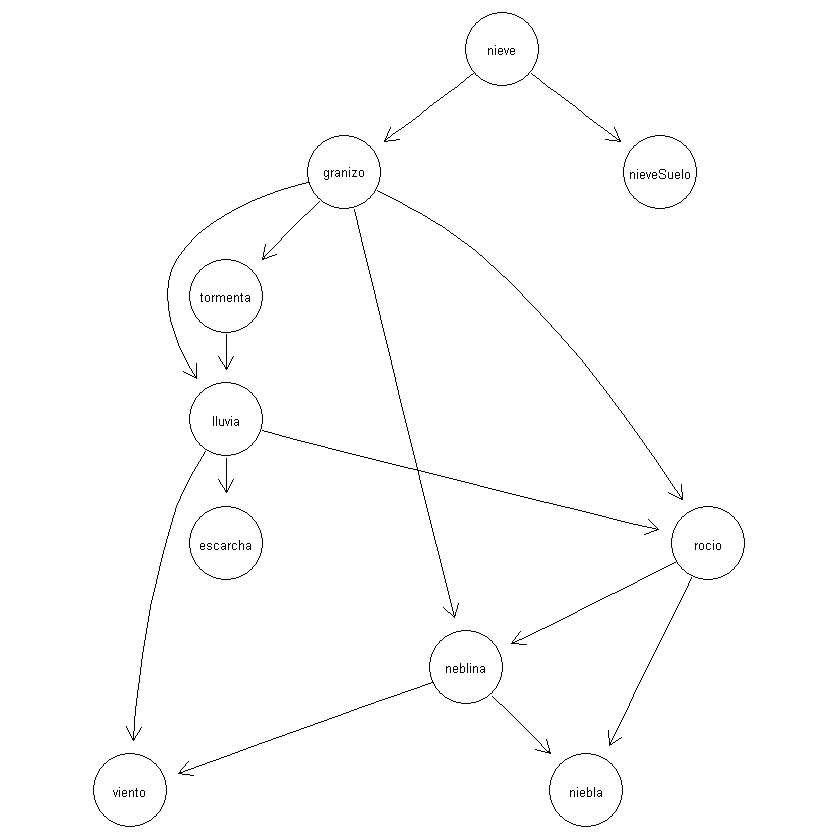

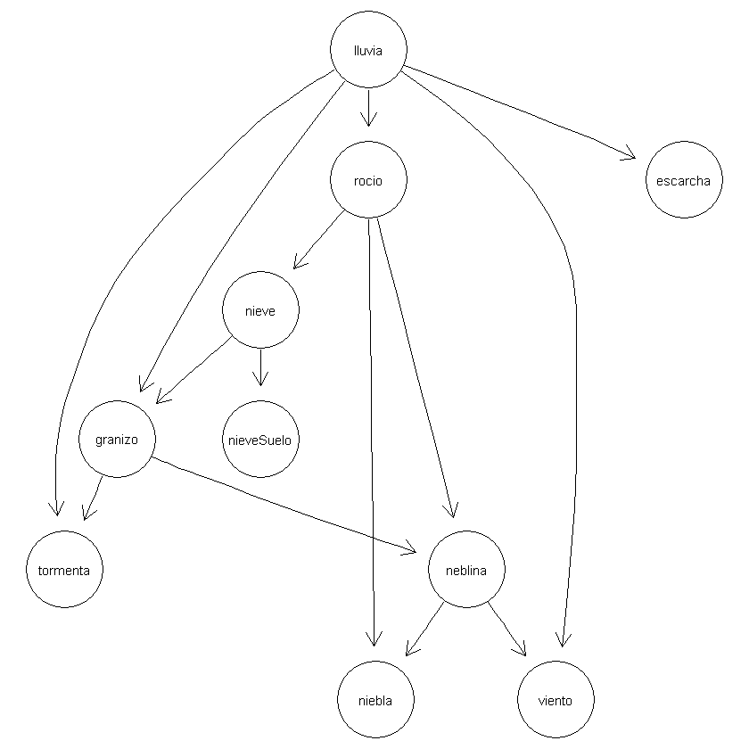

```r
graphviz.plot(hill)
graphviz.plot(tabu)
graphviz.plot(dag)
```

```r
#Veamos la "fuerza" de los arcos para cada caso



print('HILL-CLIMBING')
arc.strength(hill, meteor, criterion = "x2")
print('VORAZ-TABU')
arc.strength(tabu, meteor, criterion = "x2")
print('ORIGINAL')
arc.strength(dag, meteor, criterion = "x2")
```

```
[1] "HILL-CLIMBING"
```

| from | to | strength |
| --- | --- | --- |
| lluvia | rocio | 2.942854e-89 |
| rocio | neblina | 1.244929e-52 |
| lluvia | viento | 8.939417e-39 |
| granizo | tormenta | 3.189229e-104 |
| tormenta | lluvia | 3.887150e-25 |
| neblina | viento | 3.343866e-34 |
| neblina | niebla | 8.140958e-19 |
| lluvia | escarcha | 8.743909e-12 |
| nieve | nieveSuelo | 2.515328e-101 |
| nieve | granizo | 1.243591e-28 |
| rocio | niebla | 4.868168e-09 |
| granizo | neblina | 7.668544e-08 |
| granizo | rocio | 3.046056e-03 |
| granizo | lluvia | 6.711390e-04 |

```
[1] "VORAZ-TABU"
```

| from | to | strength |
| --- | --- | --- |
| lluvia | rocio | 1.102135e-95 |
| rocio | neblina | 1.244929e-52 |
| lluvia | viento | 8.939417e-39 |
| neblina | viento | 3.343866e-34 |
| neblina | niebla | 8.140958e-19 |
| rocio | niebla | 4.868168e-09 |
| granizo | neblina | 7.668544e-08 |
| lluvia | granizo | 1.439193e-12 |
| lluvia | tormenta | 3.887150e-25 |
| granizo | tormenta | 4.769820e-64 |
| nieve | granizo | 7.327231e-122 |
| lluvia | escarcha | 8.743909e-12 |
| nieve | nieveSuelo | 2.515328e-101 |
| rocio | nieve | 1.123882e-02 |

```
[1] "ORIGINAL"
```

| from | to | strength |
| --- | --- | --- |
| viento | lluvia | 5.887107e-48 |
| viento | rocio | 1.730098e-23 |
| viento | niebla | 1.591451e-05 |
| rocio | niebla | 2.087399e-17 |
| rocio | escarcha | 2.106559e-05 |
| niebla | neblina | 1.300969e-27 |
| lluvia | tormenta | 1.707081e-33 |
| tormenta | granizo | 3.189229e-104 |
| tormenta | nieve | 1.051550e-13 |
| nieve | nieveSuelo | 2.515328e-101 |

```r
dag
```

```
  Random/Generated Bayesian network

  model:
   [viento][lluvia|viento][rocio|viento][escarcha|rocio][niebla|rocio:viento]
   [tormenta|lluvia][granizo|tormenta][neblina|niebla][nieve|tormenta]
   [nieveSuelo|nieve]
  nodes:                                 10
  arcs:                                  10
    undirected arcs:                     0
    directed arcs:                       10
  average markov blanket size:           2.00
  average neighbourhood size:            2.00
  average branching factor:              1.00

  generation algorithm:                  Empty
```